# A Generalized Linear Model in R

Ariella Rink

2022-06-09

## Background

We are going to be looking at how well relative difference in hind femur size between competing males predicts whether resident males win fights against intruding male monkey beetles *Heterochelus chiragricus*. Fights occur on flowers and generally start when an incoming male (the intruder) spots a male already on the flower (the resident), guarding a female. Males fight by wrestling with their hind legs, and I measured several aspects of hind leg size. Here we will focus on the size of the hind femurs.

## Reading in and cleaning the data

We’ll first read in a .csv [file](https://github.com/ariellanr/DataAnalystPortfolio/blob/main/beetle_fights_chiragricus.csv) containing the following variables: - fight | an alphanumeric key uniquely identifying each fight - dur | duration of the fight (measured in seconds) - res.win | a binary variable indicating whether the resident male won (1) or lost (0) the fight - res.f.cs | femur size of the resident male (cs = centroid size, a size value derived using geometric morphometric methods) - intr.f.cs | femur size of the intruder male (cs = centroid size, a size value derived using geometric morphometric methods) - logdiff.fcs | relative difference in femur size between resident and intruder, expressed as the difference between the natural logarithms of each value. See [this paper](https://www.sciencedirect.com/science/article/abs/pii/S0022249614000054) and this [CrossValidated thread](https://stats.stackexchange.com/questions/244199/why-is-it-that-natural-log-changes-are-percentage-changes-what-is-about-logs-th) for more information.

Each row contains data pertaining to one contest.

```r
data<-read.csv("beetle_fights_chiragricus.csv",header=TRUE, sep=",", na.strings="NA", dec=".", strip.white=TRUE, encoding="UTF-8")
data<-na.omit(data)
head(data)
```

```
##   fight dur res.win res.f.cs intr.f.cs  logdiff.fcs
## 1    A1 120       0 7.401162  7.796530 -0.052041830
## 2  A201   2       0 5.719088  7.079838 -0.213441717
## 3  A202  60       0 7.216150  7.264181 -0.006633985
## 4  A203  30       0 4.960003  6.674864 -0.296942443
## 5  A204  20       0 7.009814  8.142722 -0.149813395
## 6  A205 120       0 5.941225  6.696879 -0.119726256
```

## Exploring the data

We are interested in modelling `res.win` as a function of `logdiff.fcs`. Let’s have a look at `logdiff.fcs` and also the actual femur size of each competitor, `res.f.cs` and `intr.f.cs`.

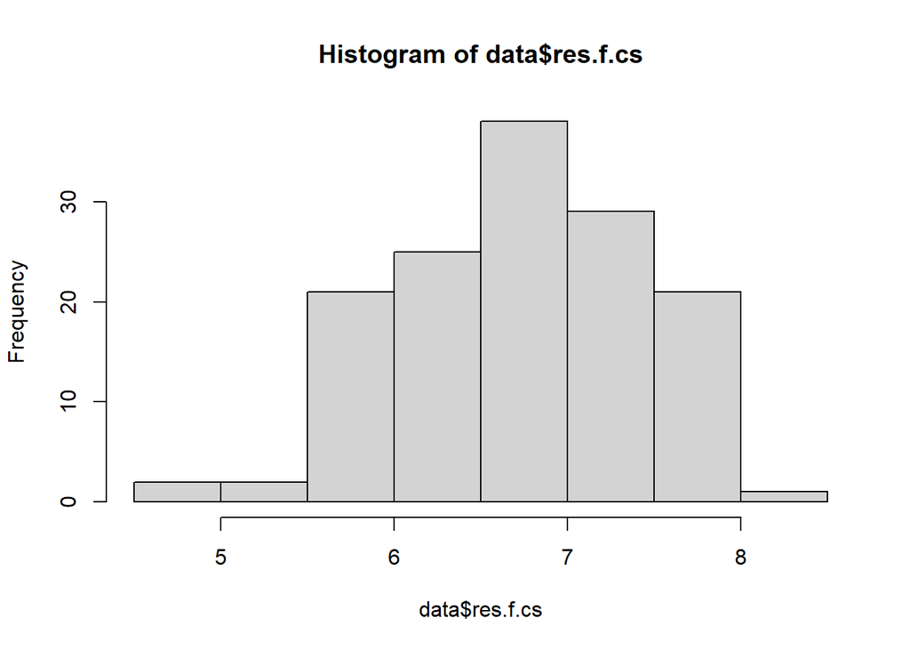

```r
hist(data$res.f.cs)
```

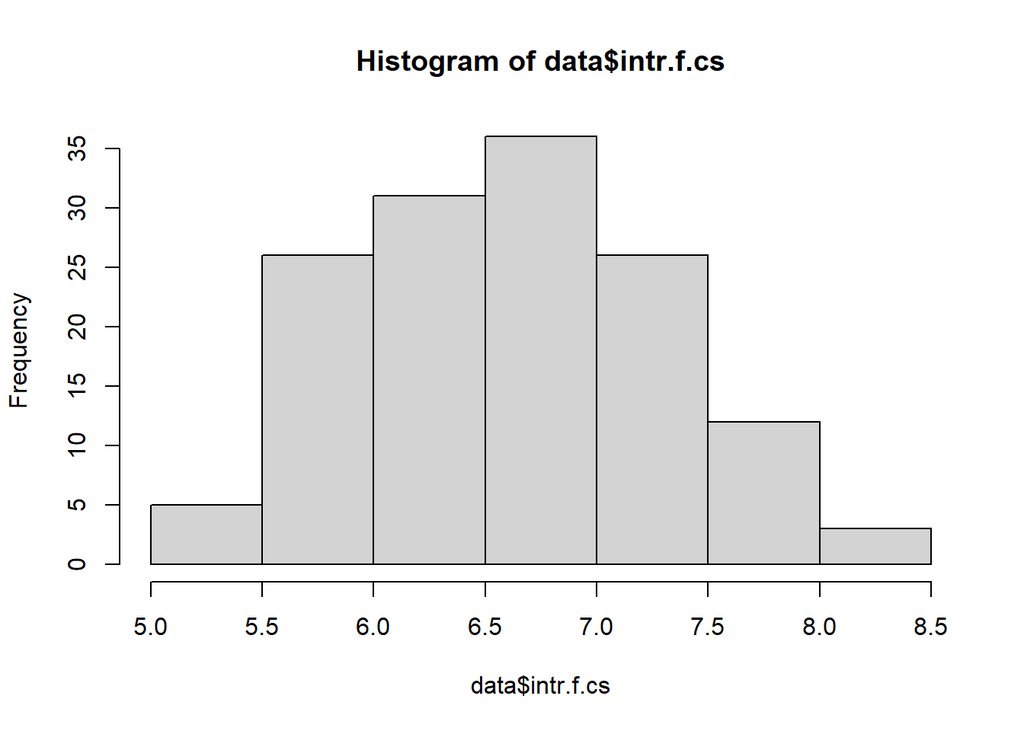

```r
hist(data$intr.f.cs)
```

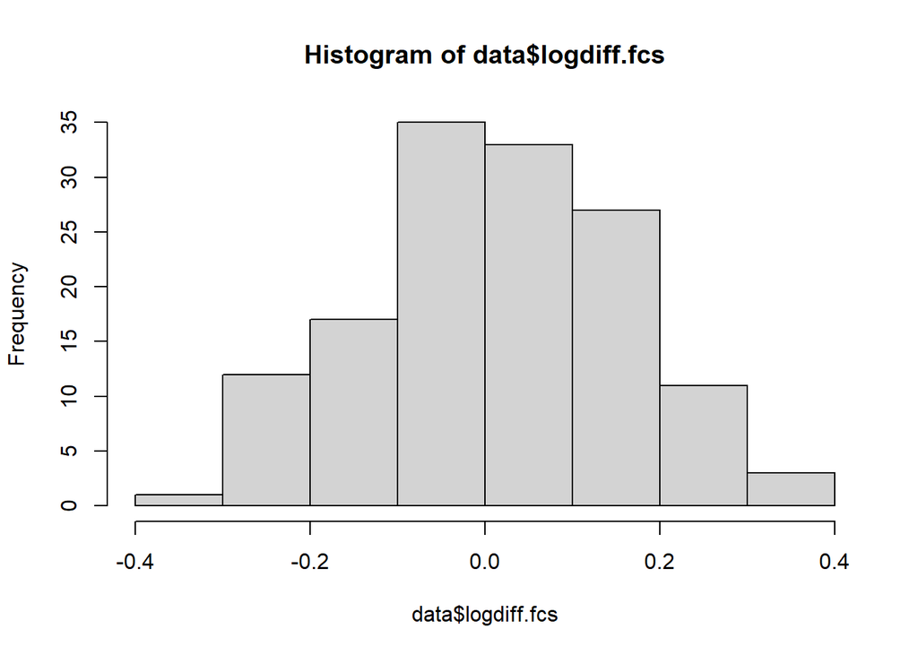

```r
hist(data$logdiff.fcs)
```

Each variable looks more or less normally distributed. Let’s do a Shapiro-Wilk test of normality on each to check.

```r
shapiro.test(data$res.f.cs)
```

```
##
##  Shapiro-Wilk normality test
##
## data:  data$res.f.cs
## W = 0.9811, p-value = 0.0513
```

```r
shapiro.test(data$intr.f.cs)
```

```
##
##  Shapiro-Wilk normality test
##
## data:  data$intr.f.cs
## W = 0.99205, p-value = 0.6267
```

```r
shapiro.test(data$logdiff.fcs)
```

```
##
##  Shapiro-Wilk normality test
##
## data:  data$logdiff.fcs
## W = 0.99555, p-value = 0.9489
```

Great! All three tests return p-values of >0.05, which means that the alternative hypothesis of non-normal distribution is not supported i.e., we can assume that these variables are normally distributed.

## The model

Our dependent variable (`res.win`) is binary, which suits our data to being explored using a generalized linear model with family set to binomial. Different families can be specified depending on the structure of the data.

```r
win.femsize<-glm(res.win~logdiff.fcs,family=binomial(logit),data=data)
summary(win.femsize)
```

```
##
## Call:
## glm(formula = res.win ~ logdiff.fcs, family = binomial(logit),
##     data = data)
##
## Deviance Residuals:
##     Min       1Q   Median       3Q      Max
## -2.4187  -0.6879   0.3767   0.7110   1.9445
##
## Coefficients:
##             Estimate Std. Error z value Pr(>|z|)
## (Intercept)   1.0648     0.2369   4.495 6.96e-06 ***
## logdiff.fcs  10.7889     2.0363   5.298 1.17e-07 ***
## ---
## Signif. codes:  0 '***' 0.001 '**' 0.01 '*' 0.05 '.' 0.1 ' ' 1
##
## (Dispersion parameter for binomial family taken to be 1)
##
##     Null deviance: 168.62  on 138  degrees of freedom
## Residual deviance: 124.04  on 137  degrees of freedom
## AIC: 128.04
##
## Number of Fisher Scoring iterations: 5
```

Looking at the summary of the model output, we can see that the larger the relative difference between the resident and intruders’ femur sizes, the more likely the resident is to win. Bigger legs = good for fighting beetles!

## Let’s visualise this and run some predictions

```r
plot(data$res.win~data$logdiff.fcs,main="",ylab="Probability of resident winning",xlab="Relative difference in femur centroid size",las=1)
x <- seq(-0.3588946, 0.3938675, length = 131)
y <- predict(win.femsize, data.frame(logdiff.fcs=x),type="response")
lines(x,y)

# Calculate standard error for our prediction...
y.se<-predict(win.femsize, data.frame(logdiff.fcs=x),type="response",se.fit=T)
UL<- y + y.se$se.fit*1.96
LL<- y - y.se$se.fit*1.96

# Shade in the area encompassing the standard error...
par(new=TRUE)
polygon(c(rev(x),x),c(rev(UL),LL),col=rgb(0.5,0.5,0.5,0.2),border=F)

# Add a legend...
legend(0.1,0.3, legend=c("Intercept","Equal probability"),lty=c(2,3),bty="n")

# Intercept line to highlight probability of resident winning when there is no difference in femur size between him and his opponent
yval<-predict(win.femsize,data.frame(logdiff.fcs=0),type="resp")
xmin<-min(data$logdiff.fcs)
clip(x1=xmin,x2=0,y1=0,y2=yval)
abline(h=yval,v=0,lty=2)

# What is the size difference at which either opponent is equally likely to win?
findInt <- function(model, value) {
  function(x) {
    predict(model, data.frame(logdiff.fcs=x), type="response") - value
  }
}
equal<-uniroot(findInt(win.femsize, .5), range(data$logdiff.fcs))$root
equal
```

```
## [1] -0.09870349
```

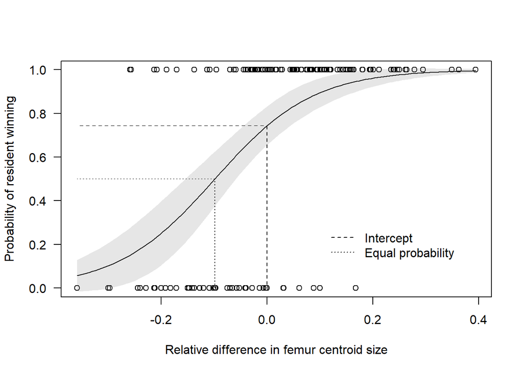

```r
# Let's plot this...
clip(x1=xmin,x2=equal,y1=0,y2=0.5)
abline(h=0.5,v=equal,lty=3)
```

Opponents are equally likely to win when the relative log difference between intruder and resident femur size is ~9.87%. As an example, take a resident male with femur size = 5. In order for an intruder to be as likely as this resident to win a contest, the intruder will need to have femurs of size:

```r
5*exp(-equal)
```

```
## [1] 5.518695
```

And if both contestants have the same femur size (i.e. relative difference in femur size = 0), then the oods that the resident male will win are:

```r
exp(coefficients(win.femsize))[1]
```

```
## (Intercept)
##     2.90018
```

Which means that the resident is approximately 2.90 times more likely than the intruder to win a size-matched contest.